# RiboSeq_Report

11 August 2021

The following document is a report on the alignment of multiple Ribo-Seq datasets against NMD and RI transcripts as well as against the human genome. These alignments are then analyzed in respect to their mapping against the previously determined unique Regions of the also previously determined split-ORFs.

## Alignment against NMD transcripts

The thresholds for each dataset are determined by calculating the average relative read count (number of reads per bp) aligning to randomly selected regions of the 3’UTR-regions of the longest isoforms of all coding transcripts.

Thresholds for each dataset

|  | Threshold |
| --- | --- |
| Adeno_ctrl1_vs_NMD | 0.0006636 |
| Adeno_ctrl2_vs_NMD | 0.0001719 |
| Adeno_sh1_vs_NMD | 0.0001557 |
| Adeno_sh2_vs_NMD | 0.0007685 |
| Harr_vs_NMD | 0.0217920 |
| hs_iPScm_01_Ri_vs_NMD | 0.0509624 |
| RiboLace_vs_NMD | 0.0000407 |
| NSC_vs_NMD | 0.0000755 |
| Leukemia_1_vs_NMD | 0.0346454 |
| Leukemia_2_vs_NMD | 0.0421138 |
| LTM_rep1_vs_NMD | 0.0058037 |
| LTM_rep2_vs_NMD | 0.0491941 |

Average relative counts of non-unique regions for each dataset

|  | Average relative count |
| --- | --- |
| Adeno_ctrl1_vs_NMD | 0.0003791 |
| Adeno_ctrl2_vs_NMD | 0.0003291 |
| Adeno_sh1_vs_NMD | 0.0001596 |
| Adeno_sh2_vs_NMD | 0.0005578 |
| Harr_vs_NMD | 0.0000165 |
| hs_iPScm_01_Ri_vs_NMD | 0.0265090 |
| RiboLace_vs_NMD | 0.0000058 |
| NSC_vs_NMD | 0.0000265 |
| Leukemia_1_vs_NMD | 0.0082112 |
| Leukemia_2_vs_NMD | 0.0123906 |
| LTM_rep1_vs_NMD | 0.0000122 |
| LTM_rep2_vs_NMD | 0.0000234 |

Regions above the threshold

|  | Number of unique regions with relative count >= threshold |
| --- | --- |
| Adeno_ctrl1_vs_NMD | 70 |
| Adeno_ctrl2_vs_NMD | 64 |
| Adeno_sh1_vs_NMD | 24 |
| Adeno_sh2_vs_NMD | 111 |
| Harr_vs_NMD | 3 |
| hs_iPScm_01_Ri_vs_NMD | 1317 |
| RiboLace_vs_NMD | 3 |
| NSC_vs_NMD | 12 |
| Leukemia_1_vs_NMD | 672 |
| Leukemia_2_vs_NMD | 844 |
| LTM_rep1_vs_NMD | 2 |
| LTM_rep2_vs_NMD | 2 |

### The following table shows the top five unique regions with a relative count above the threshold (if available).

Adeno_ctrl1_vs_NMD

| ID | start | stop | read_count | relative_count |
| --- | --- | --- | --- | --- |
| ENSG00000063177\|ENST00000549370:ORF-19335:181:592 | 390 | 411 | 34 | 1.619050 |
| ENSG00000067225\|ENST00000567118:ORF-25574:158:1709 | 1097 | 1252 | 210 | 1.354840 |
| ENSG00000085662\|ENST00000434222:ORF-7015:40:832 | 743 | 792 | 40 | 0.816327 |
| ENSG00000182718\|ENST00000676687:ORF-46959:146:614 | 448 | 468 | 9 | 0.450000 |
| ENSG00000084623\|ENST00000676837:ORF-47627:27:321 | 250 | 294 | 18 | 0.409091 |

Adeno_ctrl2_vs_NMD

| ID | start | stop | read_count | relative_count |
| --- | --- | --- | --- | --- |
| ENSG00000063177\|ENST00000549370:ORF-19335:181:592 | 390 | 411 | 41 | 1.952380 |
| ENSG00000067225\|ENST00000567118:ORF-25574:158:1709 | 1097 | 1252 | 162 | 1.045160 |
| ENSG00000085662\|ENST00000434222:ORF-7015:40:832 | 743 | 792 | 35 | 0.714286 |
| ENSG00000006327\|ENST00000574699:ORF-25319:30:315 | 94 | 225 | 63 | 0.480916 |
| ENSG00000161960\|ENST00000581544:ORF-27696:162:1008 | 618 | 737 | 49 | 0.411765 |

Adeno_sh1_vs_NMD

| ID | start | stop | read_count | relative_count |
| --- | --- | --- | --- | --- |
| ENSG00000085662\|ENST00000434222:ORF-7015:40:832 | 743 | 792 | 27 | 0.5510200 |
| ENSG00000063177\|ENST00000549370:ORF-19335:181:592 | 390 | 411 | 11 | 0.5238100 |
| ENSG00000067225\|ENST00000567118:ORF-25574:158:1709 | 1097 | 1252 | 70 | 0.4516130 |
| ENSG00000161016\|ENST00000529920:ORF-24490:541:874 | 0 | 57 | 21 | 0.3684210 |
| ENSG00000006327\|ENST00000574699:ORF-25319:30:315 | 94 | 225 | 13 | 0.0992366 |

Adeno_sh2_vs_NMD

| ID | start | stop | read_count | relative_count |
| --- | --- | --- | --- | --- |
| ENSG00000063177\|ENST00000549370:ORF-19335:181:592 | 390 | 411 | 46 | 2.190480 |
| ENSG00000085662\|ENST00000434222:ORF-7015:40:832 | 743 | 792 | 106 | 2.163270 |
| ENSG00000067225\|ENST00000567118:ORF-25574:158:1709 | 1097 | 1252 | 293 | 1.890320 |
| ENSG00000161016\|ENST00000529920:ORF-24490:541:874 | 0 | 57 | 45 | 0.789474 |
| ENSG00000182718\|ENST00000676687:ORF-46959:146:614 | 448 | 468 | 13 | 0.650000 |

Harr_vs_NMD

| ID | start | stop | read_count | relative_count |
| --- | --- | --- | --- | --- |
| ENSG00000173559\|ENST00000307849:ORF-836:479:884 | 302 | 405 | 179 | 1.7378600 |
| ENSG00000108231\|ENST00000635953:ORF-29755:982:2125 | 313 | 1143 | 127 | 0.1530120 |
| ENSG00000099783\|ENST00000600806:ORF-36044:329:2117 | 118 | 232 | 6 | 0.0526316 |

hs_iPScm_01_Ri_vs_NMD

| ID | start | stop | read_count | relative_count |
| --- | --- | --- | --- | --- |
| ENSG00000140416\|ENST00000558347:ORF-25598:75:549 | 241 | 474 | 24630 | 105.7080 |
| ENSG00000140416\|ENST00000558347:ORF-25600:554:812 | 113 | 258 | 15037 | 103.7030 |
| ENSG00000140416\|ENST00000558347:ORF-25600:554:812 | 0 | 92 | 3461 | 37.6196 |
| ENSG00000140416\|ENST00000558544:ORF-16688:212:689 | 120 | 311 | 5238 | 27.4241 |
| ENSG00000121769\|ENST00000498148:ORF-15829:59:329 | 246 | 270 | 496 | 20.6667 |

RiboLace_vs_NMD

| ID | start | stop | read_count | relative_count |
| --- | --- | --- | --- | --- |
| ENSG00000178665\|ENST00000411863:ORF-2960:726:882 | 87 | 156 | 12 | 0.1739130 |
| ENSG00000178665\|ENST00000411863:ORF-2962:901:2314 | 0 | 168 | 12 | 0.0714286 |
| ENSG00000108231\|ENST00000635953:ORF-29755:982:2125 | 313 | 1143 | 5 | 0.0060241 |

NSC_vs_NMD

| ID | start | stop | read_count | relative_count |
| --- | --- | --- | --- | --- |
| ENSG00000161016\|ENST00000529920:ORF-24490:541:874 | 0 | 57 | 17 | 0.2982460 |
| ENSG00000123349\|ENST00000676468:ORF-43449:43:301 | 176 | 199 | 4 | 0.1739130 |
| ENSG00000097021\|ENST00000377860:ORF-3338:58:910 | 733 | 806 | 8 | 0.1095890 |
| ENSG00000125835\|ENST00000474384:ORF-9581:42:255 | 156 | 213 | 6 | 0.1052630 |
| ENSG00000173660\|ENST00000496387:ORF-15788:224:482 | 0 | 62 | 5 | 0.0806452 |

Leukemia_1_vs_NMD

| ID | start | stop | read_count | relative_count |
| --- | --- | --- | --- | --- |
| ENSG00000161016\|ENST00000529920:ORF-24490:541:874 | 0 | 57 | 636 | 11.15790 |
| ENSG00000173660\|ENST00000496387:ORF-15788:224:482 | 0 | 62 | 477 | 7.69355 |
| ENSG00000123349\|ENST00000676468:ORF-43449:43:301 | 176 | 199 | 157 | 6.82609 |
| ENSG00000008988\|ENST00000676918:ORF-43730:125:485 | 333 | 360 | 164 | 6.07407 |
| ENSG00000125835\|ENST00000474384:ORF-9581:42:255 | 156 | 213 | 335 | 5.87719 |

Leukemia_2_vs_NMD

| ID | start | stop | read_count | relative_count |
| --- | --- | --- | --- | --- |
| ENSG00000161016\|ENST00000529920:ORF-24490:541:874 | 0 | 57 | 1032 | 18.10530 |
| ENSG00000173660\|ENST00000496387:ORF-15788:224:482 | 0 | 62 | 715 | 11.53230 |
| ENSG00000123349\|ENST00000676468:ORF-43449:43:301 | 176 | 199 | 262 | 11.39130 |
| ENSG00000204435\|ENST00000677758:ORF-47584:113:608 | 348 | 386 | 313 | 8.23684 |
| ENSG00000125835\|ENST00000474384:ORF-9581:42:255 | 156 | 213 | 451 | 7.91228 |

LTM_rep1_vs_NMD

| ID | start | stop | read_count | relative_count |
| --- | --- | --- | --- | --- |
| ENSG00000173559\|ENST00000307849:ORF-836:479:884 | 302 | 405 | 169 | 1.640780 |
| ENSG00000108231\|ENST00000635953:ORF-29755:982:2125 | 313 | 1143 | 170 | 0.204819 |

LTM_rep2_vs_NMD

| ID | start | stop | read_count | relative_count |
| --- | --- | --- | --- | --- |
| ENSG00000173559\|ENST00000307849:ORF-836:479:884 | 302 | 405 | 124 | 1.203880 |
| ENSG00000108231\|ENST00000635953:ORF-29755:982:2125 | 313 | 1143 | 174 | 0.209639 |

### The following plot shows how many unique regions are expressed in which dataset and how those overlap with the other data sets.

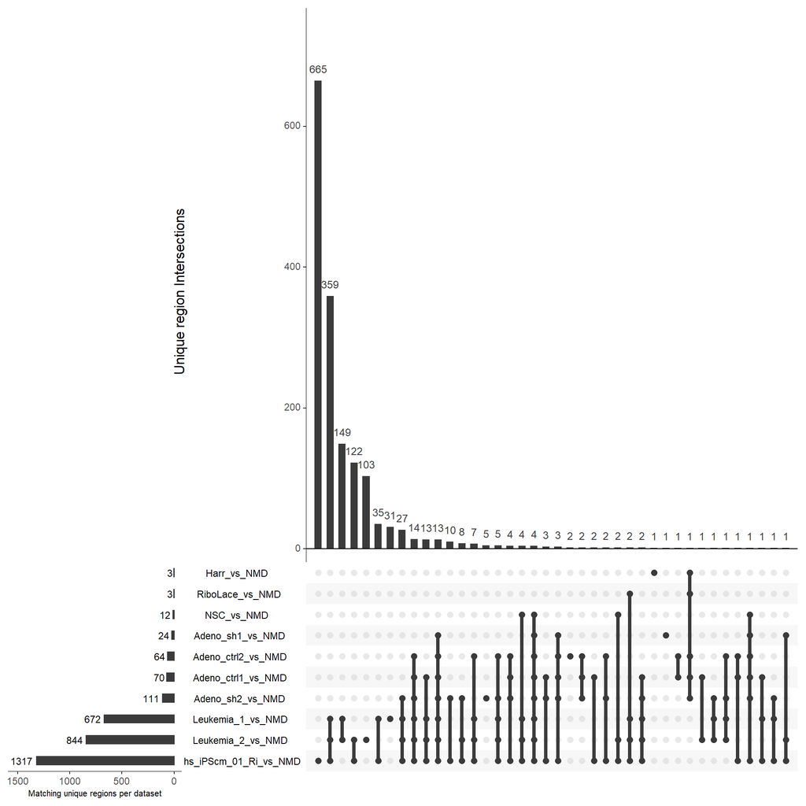

### The following shows the number of ORFs validated by Ribo-Seq and mass spectrometry and gives a list of these ORFs accordingly.

Number of ORFs validated by Ribo-seq and mass spectrometry

|  | Overlap |
| --- | --- |
| Adeno_ctrl1_vs_NMD | 6 |
| Adeno_ctrl2_vs_NMD | 5 |
| Adeno_sh1_vs_NMD | 5 |
| Adeno_sh2_vs_NMD | 7 |
| Harr_vs_NMD | 0 |
| hs_iPScm_01_Ri_vs_NMD | 64 |
| RiboLace_vs_NMD | 0 |
| NSC_vs_NMD | 2 |
| Leukemia_1_vs_NMD | 41 |
| Leukemia_2_vs_NMD | 44 |
| LTM_rep1_vs_NMD | 0 |
| LTM_rep2_vs_NMD | 0 |

| Adeno_ctrl1_vs_NMD |
| --- |
| ENSG00000067225\|ENST00000567118:ORF-25574:158:1709 |
| ENSG00000204628\|ENST00000504325:ORF-24223:231:1047 |
| ENSG00000186010\|ENST00000606722:ORF-35416:253:433 |
| ENSG00000185627\|ENST00000525665:ORF-26176:50:263 |
| ENSG00000090013\|ENST00000597870:ORF-38889:47:512 |
| ENSG00000124193\|ENST00000483871:ORF-12862:106:514 |

| Adeno_ctrl2_vs_NMD |
| --- |
| ENSG00000067225\|ENST00000567118:ORF-25574:158:1709 |
| ENSG00000204628\|ENST00000504325:ORF-24223:231:1047 |
| ENSG00000186010\|ENST00000606722:ORF-35416:253:433 |
| ENSG00000124193\|ENST00000483871:ORF-12862:106:514 |
| ENSG00000090013\|ENST00000597870:ORF-38889:47:512 |

| Adeno_sh1_vs_NMD |
| --- |
| ENSG00000067225\|ENST00000567118:ORF-25574:158:1709 |
| ENSG00000090013\|ENST00000597870:ORF-38889:47:512 |
| ENSG00000204628\|ENST00000504325:ORF-24223:231:1047 |
| ENSG00000186010\|ENST00000606722:ORF-35416:253:433 |
| ENSG00000124193\|ENST00000483871:ORF-12862:106:514 |

| Adeno_sh2_vs_NMD |
| --- |
| ENSG00000067225\|ENST00000567118:ORF-25574:158:1709 |
| ENSG00000090013\|ENST00000597870:ORF-38889:47:512 |
| ENSG00000204628\|ENST00000504325:ORF-24223:231:1047 |
| ENSG00000124193\|ENST00000483871:ORF-12862:106:514 |
| ENSG00000186010\|ENST00000606722:ORF-35416:253:433 |
| ENSG00000183207\|ENST00000596247:ORF-34855:186:1476 |
| ENSG00000128928\|ENST00000481262:ORF-10408:394:967 |

| Harr_vs_NMD |
| --- |
| No Overlap |

| hs_iPScm_01_Ri_vs_NMD |
| --- |
| ENSG00000067225\|ENST00000567118:ORF-25574:158:1709 |
| ENSG00000186010\|ENST00000606722:ORF-35416:253:433 |
| ENSG00000077522\|ENST00000652096:ORF-47306:165:957 |
| ENSG00000204628\|ENST00000504325:ORF-24223:231:1047 |
| ENSG00000124193\|ENST00000483871:ORF-12862:106:514 |
| ENSG00000048028\|ENST00000540438:ORF-15257:1043:1511 |
| ENSG00000075785\|ENST00000490093:ORF-10222:623:848 |
| ENSG00000130520\|ENST00000600289:ORF-33417:40:250 |
| ENSG00000142230\|ENST00000596995:ORF-32397:42:195 |
| ENSG00000139163\|ENST00000673406:ORF-41440:90:435 |
| ENSG00000111530\|ENST00000540319:ORF-24118:1562:1772 |
| ENSG00000196365\|ENST00000590558:ORF-39852:81:558 |
| ENSG00000067225\|ENST00000567118:ORF-25574:158:1709 |
| ENSG00000185627\|ENST00000382671:ORF-3081:12:231 |
| ENSG00000160789\|ENST00000676434:ORF-41257:882:1977 |
| ENSG00000128928\|ENST00000481262:ORF-10408:394:967 |
| ENSG00000185627\|ENST00000525665:ORF-26176:50:263 |
| ENSG00000183207\|ENST00000596247:ORF-34855:186:1476 |
| ENSG00000076685\|ENST00000675436:ORF-40996:411:2004 |
| ENSG00000104763\|ENST00000637805:ORF-38906:263:596 |
| ENSG00000160789\|ENST00000675881:ORF-45251:872:2243 |
| ENSG00000160789\|ENST00000674720:ORF-44706:375:1926 |
| ENSG00000099810\|ENST00000419385:ORF-7398:189:969 |
| ENSG00000116001\|ENST00000477044:ORF-8794:181:667 |
| ENSG00000146918\|ENST00000432615:ORF-3992:1382:1697 |
| ENSG00000117859\|ENST00000435274:ORF-4526:525:2493 |
| ENSG00000196083\|ENST00000342550:ORF-1787:951:1683 |
| ENSG00000087470\|ENST00000546649:ORF-16107:249:1851 |
| ENSG00000204628\|ENST00000508682:ORF-14634:102:546 |
| ENSG00000196083\|ENST00000413869:ORF-3086:1038:1770 |
| ENSG00000284468\|ENST00000649955:ORF-33974:181:994 |
| ENSG00000124155\|ENST00000640108:ORF-28488:25:376 |
| ENSG00000104763\|ENST00000636715:ORF-39655:168:528 |
| ENSG00000160789\|ENST00000676434:ORF-41257:882:1977 |
| ENSG00000082898\|ENST00000428210:ORF-6306:2061:2964 |
| ENSG00000119723\|ENST00000557584:ORF-21368:138:990 |
| ENSG00000006282\|ENST00000511937:ORF-14658:86:1652 |
| ENSG00000090013\|ENST00000597870:ORF-38889:47:512 |
| ENSG00000075239\|ENST00000672031:ORF-41499:40:988 |
| ENSG00000151503\|ENST00000525964:ORF-15510:290:2789 |
| ENSG00000144712\|ENST00000650119:ORF-31179:35:305 |
| ENSG00000097021\|ENST00000377860:ORF-3338:58:910 |
| ENSG00000071462\|ENST00000421744:ORF-4787:270:606 |
| ENSG00000054654\|ENST00000555612:ORF-22308:3240:5862 |
| ENSG00000145439\|ENST00000510042:ORF-19791:345:675 |
| ENSG00000127616\|ENST00000645648:ORF-37342:1637:2855 |
| ENSG00000137054\|ENST00000442009:ORF-7420:100:526 |
| ENSG00000146918\|ENST00000432615:ORF-3993:3023:3779 |
| ENSG00000085491\|ENST00000648874:ORF-38781:181:994 |
| ENSG00000151923\|ENST00000497671:ORF-21123:564:972 |
| ENSG00000102967\|ENST00000571288:ORF-26377:501:657 |
| ENSG00000141179\|ENST00000417982:ORF-6152:448:643 |
| ENSG00000105755\|ENST00000594342:ORF-38461:248:644 |
| ENSG00000125450\|ENST00000581104:ORF-32648:424:1813 |
| ENSG00000127616\|ENST00000645061:ORF-31484:66:2958 |
| ENSG00000092621\|ENST00000641491:ORF-30372:649:895 |
| ENSG00000134684\|ENST00000676297:ORF-44408:1094:1343 |
| ENSG00000134684\|ENST00000674654:ORF-46843:627:876 |
| ENSG00000090487\|ENST00000561078:ORF-19676:175:565 |
| ENSG00000051180\|ENST00000525066:ORF-14988:241:697 |
| ENSG00000092621\|ENST00000641570:ORF-38615:472:967 |
| ENSG00000140694\|ENST00000652066:ORF-35790:569:1376 |
| ENSG00000064607\|ENST00000600239:ORF-28719:71:2597 |
| ENSG00000170248\|ENST00000648706:ORF-31091:830:2894 |

| RiboLace_vs_NMD |
| --- |
| No Overlap |

| NSC_vs_NMD |
| --- |
| ENSG00000097021\|ENST00000377860:ORF-3338:58:910 |
| ENSG00000124193\|ENST00000483871:ORF-12862:106:514 |

| Leukemia_1_vs_NMD |
| --- |
| ENSG00000186010\|ENST00000606722:ORF-35416:253:433 |
| ENSG00000204628\|ENST00000504325:ORF-24223:231:1047 |
| ENSG00000075785\|ENST00000490093:ORF-10222:623:848 |
| ENSG00000067225\|ENST00000567118:ORF-25574:158:1709 |
| ENSG00000124193\|ENST00000483871:ORF-12862:106:514 |
| ENSG00000127616\|ENST00000645061:ORF-31484:66:2958 |
| ENSG00000127616\|ENST00000644327:ORF-32229:43:3142 |
| ENSG00000160789\|ENST00000674720:ORF-44706:375:1926 |
| ENSG00000185627\|ENST00000382671:ORF-3081:12:231 |
| ENSG00000146918\|ENST00000432615:ORF-3992:1382:1697 |
| ENSG00000067225\|ENST00000567118:ORF-25574:158:1709 |
| ENSG00000130520\|ENST00000600289:ORF-33417:40:250 |
| ENSG00000139163\|ENST00000673406:ORF-41440:90:435 |
| ENSG00000102967\|ENST00000571288:ORF-26377:501:657 |
| ENSG00000137054\|ENST00000442009:ORF-7420:100:526 |
| ENSG00000142230\|ENST00000596995:ORF-32397:42:195 |
| ENSG00000146918\|ENST00000432615:ORF-3993:3023:3779 |
| ENSG00000134684\|ENST00000674654:ORF-46843:627:876 |
| ENSG00000204628\|ENST00000508682:ORF-14634:102:546 |
| ENSG00000196365\|ENST00000590558:ORF-39852:81:558 |
| ENSG00000116001\|ENST00000477044:ORF-8794:181:667 |
| ENSG00000160789\|ENST00000676434:ORF-41257:882:1977 |
| ENSG00000026297\|ENST00000421787:ORF-5899:361:727 |
| ENSG00000183207\|ENST00000596247:ORF-34855:186:1476 |
| ENSG00000082898\|ENST00000428210:ORF-6306:2061:2964 |
| ENSG00000048028\|ENST00000540438:ORF-15257:1043:1511 |
| ENSG00000090013\|ENST00000597870:ORF-38889:47:512 |
| ENSG00000137054\|ENST00000442009:ORF-7420:100:526 |
| ENSG00000119723\|ENST00000557584:ORF-21368:138:990 |
| ENSG00000105755\|ENST00000594342:ORF-38461:248:644 |
| ENSG00000076685\|ENST00000675436:ORF-40996:411:2004 |
| ENSG00000134684\|ENST00000676297:ORF-44408:1094:1343 |
| ENSG00000064607\|ENST00000600239:ORF-28719:71:2597 |
| ENSG00000125450\|ENST00000581104:ORF-32648:424:1813 |
| ENSG00000185627\|ENST00000525665:ORF-26176:50:263 |
| ENSG00000075239\|ENST00000672031:ORF-41499:40:988 |
| ENSG00000145439\|ENST00000510042:ORF-19791:345:675 |
| ENSG00000170248\|ENST00000648706:ORF-31091:830:2894 |
| ENSG00000196083\|ENST00000413869:ORF-3086:1038:1770 |
| ENSG00000100038\|ENST00000457179:ORF-11548:649:1684 |
| ENSG00000128928\|ENST00000481262:ORF-10408:394:967 |

| Leukemia_2_vs_NMD |
| --- |
| ENSG00000186010\|ENST00000606722:ORF-35416:253:433 |
| ENSG00000204628\|ENST00000504325:ORF-24223:231:1047 |
| ENSG00000075785\|ENST00000490093:ORF-10222:623:848 |
| ENSG00000067225\|ENST00000567118:ORF-25574:158:1709 |
| ENSG00000124193\|ENST00000483871:ORF-12862:106:514 |
| ENSG00000146918\|ENST00000432615:ORF-3993:3023:3779 |
| ENSG00000160789\|ENST00000674720:ORF-44706:375:1926 |
| ENSG00000130520\|ENST00000600289:ORF-33417:40:250 |
| ENSG00000146918\|ENST00000432615:ORF-3992:1382:1697 |
| ENSG00000127616\|ENST00000645061:ORF-31484:66:2958 |
| ENSG00000204628\|ENST00000508682:ORF-14634:102:546 |
| ENSG00000142230\|ENST00000596995:ORF-32397:42:195 |
| ENSG00000127616\|ENST00000644327:ORF-32229:43:3142 |
| ENSG00000139163\|ENST00000673406:ORF-41440:90:435 |
| ENSG00000134684\|ENST00000676297:ORF-44408:1094:1343 |
| ENSG00000026297\|ENST00000421787:ORF-5899:361:727 |
| ENSG00000134684\|ENST00000674654:ORF-46843:627:876 |
| ENSG00000137054\|ENST00000442009:ORF-7420:100:526 |
| ENSG00000116001\|ENST00000477044:ORF-8794:181:667 |
| ENSG00000102967\|ENST00000571288:ORF-26377:501:657 |
| ENSG00000196365\|ENST00000590558:ORF-39852:81:558 |
| ENSG00000125450\|ENST00000581104:ORF-32648:424:1813 |
| ENSG00000185627\|ENST00000525665:ORF-26176:50:263 |
| ENSG00000160789\|ENST00000675881:ORF-45251:872:2243 |
| ENSG00000256269\|ENST00000640813:ORF-30330:136:760 |
| ENSG00000183207\|ENST00000596247:ORF-34855:186:1476 |
| ENSG00000105755\|ENST00000594342:ORF-38461:248:644 |
| ENSG00000090013\|ENST00000597870:ORF-38889:47:512 |
| ENSG00000128928\|ENST00000481262:ORF-10408:394:967 |
| ENSG00000185627\|ENST00000382671:ORF-3081:12:231 |
| ENSG00000067225\|ENST00000567118:ORF-25574:158:1709 |
| ENSG00000076685\|ENST00000675436:ORF-40996:411:2004 |
| ENSG00000111530\|ENST00000540319:ORF-24118:1562:1772 |
| ENSG00000100038\|ENST00000457179:ORF-11548:649:1684 |
| ENSG00000082898\|ENST00000428210:ORF-6306:2061:2964 |
| ENSG00000137054\|ENST00000442009:ORF-7420:100:526 |
| ENSG00000284752\|ENST00000642962:ORF-35307:577:1699 |
| ENSG00000170248\|ENST00000648706:ORF-31091:830:2894 |
| ENSG00000090487\|ENST00000561078:ORF-19676:175:565 |
| ENSG00000196083\|ENST00000413869:ORF-3086:1038:1770 |
| ENSG00000051180\|ENST00000525066:ORF-14988:241:697 |
| ENSG00000097021\|ENST00000377860:ORF-3338:58:910 |
| ENSG00000196083\|ENST00000342550:ORF-1787:951:1683 |
| ENSG00000119723\|ENST00000557584:ORF-21368:138:990 |

| LTM_rep1_vs_NMD |
| --- |
| No Overlap |

| LTM_rep2_vs_NMD |
| --- |
| No Overlap |

### The following shows the overlapp between the Ribo-seq and MS validated unique-Regions

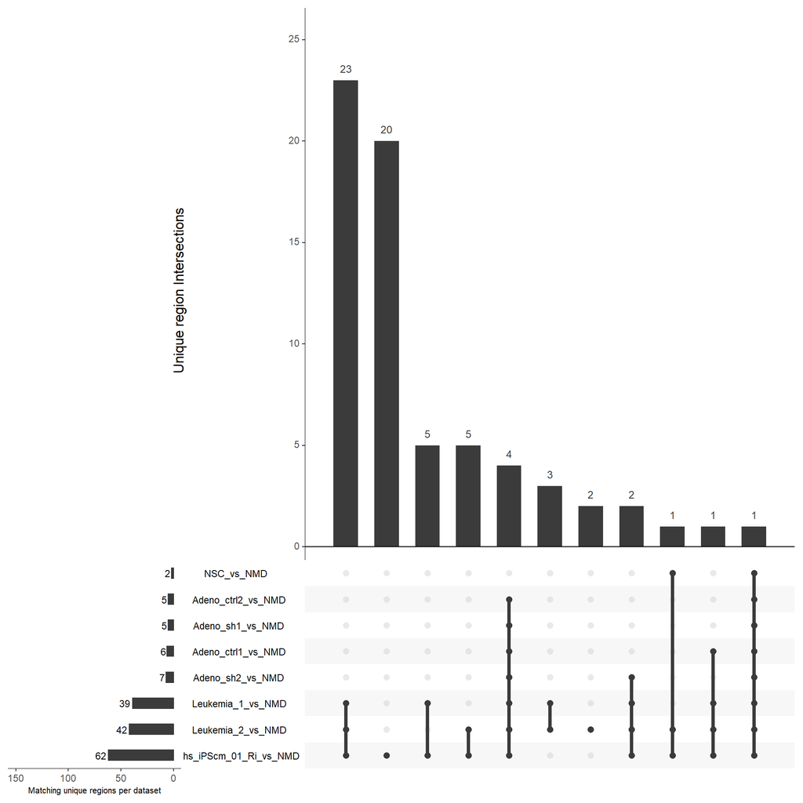

## Alignment against RI transcripts

The thresholds for each dataset are determined by calculating the average relative read count (number of reads per bp) aligning to randomly selected regions of the 3’UTR-regions of the longest isoforms of all coding transcripts.

Thresholds for each dataset

|  | Threshold |
| --- | --- |
| Adeno_ctrl1_vs_RI | 0.0000494 |
| Adeno_ctrl2_vs_RI | 0.0000578 |
| Adeno_sh1_vs_RI | 0.0363293 |
| Adeno_sh2_vs_RI | 0.0803362 |
| Harr_vs_RI | 0.0112858 |
| hs_iPScm_01_Ri_vs_RI | 0.0238240 |
| RiboLace_vs_RI | 0.0001240 |
| NSC_vs_RI | 0.0000674 |
| Leukemia_1_vs_RI | 0.0000000 |
| Leukemia_2_vs_RI | 0.0000000 |
| LTM_rep1_vs_RI | 0.0112115 |
| LTM_rep2_vs_RI | 0.0296363 |

Average relative counts of non-unique regions for each dataset

|  | Average relative count |
| --- | --- |
| Adeno_ctrl1_vs_RI | 0.0031782 |
| Adeno_ctrl2_vs_RI | 0.0034254 |
| Adeno_sh1_vs_RI | 0.0019074 |
| Adeno_sh2_vs_RI | 0.0052762 |
| Harr_vs_RI | 0.0036909 |
| hs_iPScm_01_Ri_vs_RI | 0.1492390 |
| RiboLace_vs_RI | 0.0002127 |
| NSC_vs_RI | 0.0002539 |
| Leukemia_1_vs_RI | 0.0742748 |
| Leukemia_2_vs_RI | 0.1173251 |
| LTM_rep1_vs_RI | 0.0018480 |
| LTM_rep2_vs_RI | 0.0011247 |

Regions above the threshold

|  | Number of unique regions with relative count >= Threshold |
| --- | --- |
| Adeno_ctrl1_vs_RI | 128 |
| Adeno_ctrl2_vs_RI | 120 |
| Adeno_sh1_vs_RI | 46 |
| Adeno_sh2_vs_RI | 82 |
| Harr_vs_RI | 15 |
| hs_iPScm_01_Ri_vs_RI | 1962 |
| RiboLace_vs_RI | 0 |
| NSC_vs_RI | 13 |
| Leukemia_1_vs_RI | 1143 |
| Leukemia_2_vs_RI | 1379 |
| LTM_rep1_vs_RI | 18 |
| LTM_rep2_vs_RI | 9 |

### The following table shows the top five unique regions with a relative count above the threshold (if available).

Adeno_ctrl1_vs_RI

| ID | start | stop | read_count | relative_count |
| --- | --- | --- | --- | --- |
| ENSG00000111640\|ENST00000466525:ORF-11146:293:566 | 205 | 273 | 102 | 1.500000 |
| ENSG00000111640\|ENST00000466525:ORF-11146:293:566 | 0 | 113 | 153 | 1.353980 |
| ENSG00000111640\|ENST00000466525:ORF-11147:845:1553 | 32 | 224 | 253 | 1.317710 |
| ENSG00000120708\|ENST00000506699:ORF-40551:942:1227 | 250 | 285 | 38 | 1.085710 |
| ENSG00000075415\|ENST00000546766:ORF-27812:90:459 | 157 | 369 | 189 | 0.891509 |

Adeno_ctrl2_vs_RI

| ID | start | stop | read_count | relative_count |
| --- | --- | --- | --- | --- |
| ENSG00000111640\|ENST00000466525:ORF-11146:293:566 | 205 | 273 | 84 | 1.235290 |
| ENSG00000111640\|ENST00000466525:ORF-11147:845:1553 | 32 | 224 | 233 | 1.213540 |
| ENSG00000111640\|ENST00000466525:ORF-11146:293:566 | 0 | 113 | 136 | 1.203540 |
| ENSG00000120708\|ENST00000506699:ORF-40551:942:1227 | 250 | 285 | 28 | 0.800000 |
| ENSG00000075415\|ENST00000546766:ORF-27812:90:459 | 157 | 369 | 164 | 0.773585 |

Adeno_sh1_vs_RI

| ID | start | stop | read_count | relative_count |
| --- | --- | --- | --- | --- |
| ENSG00000198467\|ENST00000471212:ORF-5689:751:1108 | 304 | 357 | 30 | 0.566038 |
| ENSG00000111640\|ENST00000466525:ORF-11146:293:566 | 205 | 273 | 34 | 0.500000 |
| ENSG00000111640\|ENST00000466525:ORF-11146:293:566 | 0 | 113 | 48 | 0.424779 |
| ENSG00000111640\|ENST00000466525:ORF-11147:845:1553 | 32 | 224 | 76 | 0.395833 |
| ENSG00000109971\|ENST00000532091:ORF-27304:455:1115 | 617 | 660 | 14 | 0.325581 |

Adeno_sh2_vs_RI

| ID | start | stop | read_count | relative_count |
| --- | --- | --- | --- | --- |
| ENSG00000111640\|ENST00000466525:ORF-11146:293:566 | 0 | 113 | 249 | 2.20354 |
| ENSG00000111640\|ENST00000466525:ORF-11147:845:1553 | 32 | 224 | 391 | 2.03646 |
| ENSG00000111640\|ENST00000466525:ORF-11146:293:566 | 205 | 273 | 138 | 2.02941 |
| ENSG00000120708\|ENST00000506699:ORF-40551:942:1227 | 250 | 285 | 42 | 1.20000 |
| ENSG00000198467\|ENST00000471212:ORF-5689:751:1108 | 304 | 357 | 63 | 1.18868 |

Harr_vs_RI

| ID | start | stop | read_count | relative_count |
| --- | --- | --- | --- | --- |
| ENSG00000120071\|ENST00000573286:ORF-50159:3957:4422 | 267 | 465 | 777 | 3.924240 |
| ENSG00000172890\|ENST00000531236:ORF-34840:2626:3286 | 605 | 660 | 59 | 1.072730 |
| ENSG00000172932\|ENST00000513750:ORF-37373:1162:1417 | 31 | 255 | 204 | 0.910714 |
| ENSG00000105819\|ENST00000469560:ORF-6778:1066:1249 | 87 | 163 | 68 | 0.894737 |
| ENSG00000172932\|ENST00000512231:ORF-27439:1162:1417 | 31 | 255 | 193 | 0.861607 |

hs_iPScm_01_Ri_vs_RI

| ID | start | stop | read_count | relative_count |
| --- | --- | --- | --- | --- |
| ENSG00000140416\|ENST00000560975:ORF-34091:146:437 | 114 | 291 | 6039 | 34.1186 |
| ENSG00000173641\|ENST00000442459:ORF-2286:80:287 | 82 | 109 | 917 | 33.9630 |
| ENSG00000075624\|ENST00000462494:ORF-4517:84:642 | 363 | 558 | 6379 | 32.7128 |
| ENSG00000149925\|ENST00000564521:ORF-36241:93:480 | 327 | 387 | 1893 | 31.5500 |
| ENSG00000092841\|ENST00000548725:ORF-39533:294:570 | 95 | 186 | 1732 | 19.0330 |

RiboLace_vs_RI

| ID | start | stop | read_count | relative_count |
| --- | --- | --- | --- | --- |
| NA | NA | NA | NA | NA |

NSC_vs_RI

| ID | start | stop | read_count | relative_count |
| --- | --- | --- | --- | --- |
| ENSG00000115053\|ENST00000676798:ORF-61386:1994:2771 | 746 | 777 | 4 | 0.1290320 |
| ENSG00000248098\|ENST00000538423:ORF-22727:20:464 | 76 | 108 | 4 | 0.1250000 |
| ENSG00000135486\|ENST00000679228:ORF-64881:59:272 | 136 | 213 | 7 | 0.0909091 |
| ENSG00000196365\|ENST00000587552:ORF-55071:388:1291 | 828 | 903 | 5 | 0.0666667 |
| ENSG00000133313\|ENST00000584581:ORF-51685:2865:3027 | 79 | 162 | 5 | 0.0602410 |

Leukemia_1_vs_RI

| ID | start | stop | read_count | relative_count |
| --- | --- | --- | --- | --- |
| ENSG00000131238\|ENST00000641236:ORF-51833:12:285 | 235 | 273 | 1014 | 26.68420 |
| ENSG00000109971\|ENST00000532091:ORF-27304:455:1115 | 617 | 660 | 677 | 15.74420 |
| ENSG00000108107\|ENST00000426763:ORF-2839:1529:1736 | 40 | 207 | 2454 | 14.69460 |
| ENSG00000115053\|ENST00000676798:ORF-61386:1994:2771 | 746 | 777 | 394 | 12.70970 |
| ENSG00000156508\|ENST00000491404:ORF-14527:573:1818 | 885 | 1245 | 3084 | 8.56667 |

Leukemia_2_vs_RI

| ID | start | stop | read_count | relative_count |
| --- | --- | --- | --- | --- |
| ENSG00000131238\|ENST00000641236:ORF-51833:12:285 | 235 | 273 | 1466 | 38.5789 |
| ENSG00000109971\|ENST00000532091:ORF-27304:455:1115 | 617 | 660 | 975 | 22.6744 |
| ENSG00000108107\|ENST00000426763:ORF-2839:1529:1736 | 40 | 207 | 3370 | 20.1796 |
| ENSG00000115053\|ENST00000676798:ORF-61386:1994:2771 | 746 | 777 | 596 | 19.2258 |
| ENSG00000156508\|ENST00000491404:ORF-14527:573:1818 | 885 | 1245 | 4398 | 12.2167 |

LTM_rep1_vs_RI

| ID | start | stop | read_count | relative_count |
| --- | --- | --- | --- | --- |
| ENSG00000120071\|ENST00000573286:ORF-50159:3957:4422 | 267 | 465 | 1147 | 5.792930 |
| ENSG00000105819\|ENST00000469560:ORF-6778:1066:1249 | 87 | 163 | 100 | 1.315790 |
| ENSG00000172932\|ENST00000513750:ORF-37373:1162:1417 | 31 | 255 | 216 | 0.964286 |
| ENSG00000081692\|ENST00000485807:ORF-12237:1287:1782 | 0 | 62 | 59 | 0.951613 |
| ENSG00000172932\|ENST00000512231:ORF-27439:1162:1417 | 31 | 255 | 212 | 0.946429 |

LTM_rep2_vs_RI

| ID | start | stop | read_count | relative_count |
| --- | --- | --- | --- | --- |
| ENSG00000120071\|ENST00000573286:ORF-50159:3957:4422 | 267 | 465 | 560 | 2.828280 |
| ENSG00000172932\|ENST00000512231:ORF-27439:1162:1417 | 31 | 255 | 196 | 0.875000 |
| ENSG00000105819\|ENST00000469560:ORF-6778:1066:1249 | 87 | 163 | 61 | 0.802632 |
| ENSG00000172932\|ENST00000513750:ORF-37373:1162:1417 | 31 | 255 | 165 | 0.736607 |
| ENSG00000081692\|ENST00000485807:ORF-12237:1287:1782 | 0 | 62 | 37 | 0.596774 |

### The following plot shows how many unique regions are expressed in which dataset and how those overlap with the other data sets.

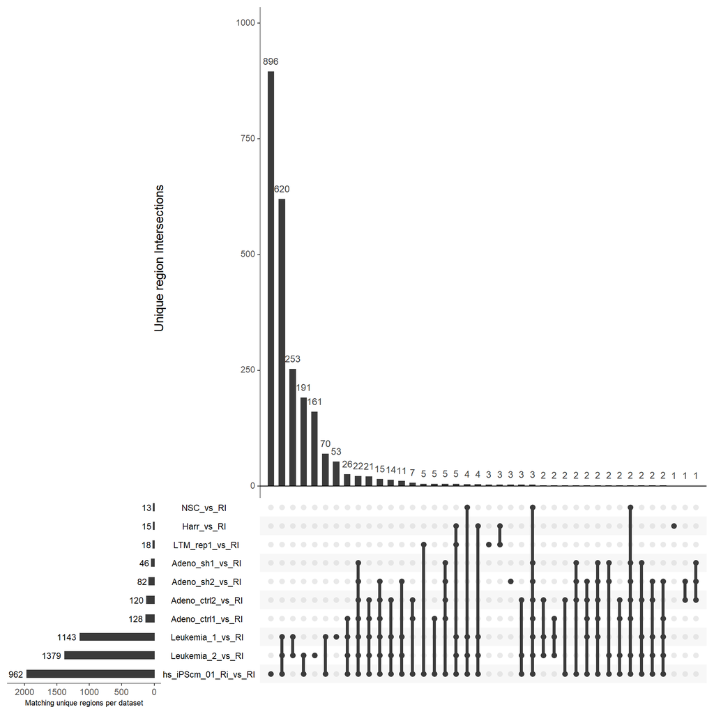